# Bayesian modeling and prediction for movies

## Setup

### Load packages

```r
library(ggplot2)
library(dplyr)
library(statsr)
library(BAS)
library(tidyr)
library(gridExtra)
library(MASS)
library(GGally)
```

### Load data

```r
load("movies.Rdata")
```

## Part 1: Data

IMDb and Rotten Tomatoes are two of the most popular rating websites for movies. Both of these websites provide two sets of ratings: critics scores and audience scores, as well as numerous other variables about the movies. Our dataset is comprised of 651 randomly sampled movies produced and released before 2016. Each row in the dataset corresponds to a movie, and every column of the table represents a particular characteristic of a movie. There are 32 available variables.

- **Generalizability**: Conclusions made from this data set are generalizable because movies were randomly selected. The results are generalizable to movies produced and released before 2016.
- **Causality**: This is an observational study with no random assignment, therefore we cannot infer causality.
- **Potential biases*: Most rating systems suffer from self-selection bias since only highly motivated individuals commit to voting and ranking the movies. In addition, one person can post multiple comments and affect the ranking.

## Part 2: Data manipulation

We are first going to perform feature engineering to create new variables for our exploratory data analysis. Below is the summary of new variables, derived from existing variables in the dataset.

- *feature_film*: “yes” if title type is feature film, “no” otherwise
- *drama*: “yes” if film genre is drama, “no” otherwise runtime
- *mpaa_rating_R*: “yes” for R rated movie, “no” otherwise
- *oscar_season*: “yes” if movie is released in theaters in November, October, or December, “no” otherwise
- *summer_season*: “yes” if movie is released in theaters in May, June, July, or August, “no” otherwise

```r
movies <- movies %>%
  mutate(feature_film = ifelse(title_type == "Feature Film", "yes", "no"),
         drama = ifelse(genre == "Drama", "yes", "no"),
         mpaa_rating_R = ifelse(mpaa_rating == "R","yes","no"),
         oscar_season = ifelse(thtr_rel_month == 11 | thtr_rel_month == 10 | thtr_rel_month == 12, "yes", "no"),
         summer_season = ifelse(thtr_rel_month == 5 | thtr_rel_month == 6 | thtr_rel_month == 7 | thtr_rel_month == 8, "yes","no"))
```

## Part 3: Exploratory data analysis

Dataframe “movies” consists of 651 observations of 37 variables.

```r
str(movies)
```

```
## Classes 'tbl_df', 'tbl' and 'data.frame':    651 obs. of  37 variables:
##  $ title           : chr  "Filly Brown" "The Dish" "Waiting for Guffman" "The Age of Innocence" ...
##  $ title_type      : Factor w/ 3 levels "Documentary",..: 2 2 2 2 2 1 2 2 1 2 ...
##  $ genre           : Factor w/ 11 levels "Action & Adventure",..: 6 6 4 6 7 5 6 6 5 6 ...
##  $ runtime         : num  80 101 84 139 90 78 142 93 88 119 ...
##  $ mpaa_rating     : Factor w/ 6 levels "G","NC-17","PG",..: 5 4 5 3 5 6 4 5 6 6 ...
##  $ studio          : Factor w/ 211 levels "20th Century Fox",..: 91 202 167 34 13 163 147 118 88 84 ...
##  $ thtr_rel_year   : num  2013 2001 1996 1993 2004 ...
##  $ thtr_rel_month  : num  4 3 8 10 9 1 1 11 9 3 ...
##  $ thtr_rel_day    : num  19 14 21 1 10 15 1 8 7 2 ...
##  $ dvd_rel_year    : num  2013 2001 2001 2001 2005 ...
##  $ dvd_rel_month   : num  7 8 8 11 4 4 2 3 1 8 ...
##  $ dvd_rel_day     : num  30 28 21 6 19 20 18 2 21 14 ...
##  $ imdb_rating     : num  5.5 7.3 7.6 7.2 5.1 7.8 7.2 5.5 7.5 6.6 ...
##  $ imdb_num_votes  : int  899 12285 22381 35096 2386 333 5016 2272 880 12496 ...
```

[output cut: 23 more lines]

For conducting the exploratory data analysis of the relationship between audience_score and the new variables, we will create a subset of the full dataset, only containing the required data.

```r
df <- movies[c("feature_film", "drama", "mpaa_rating_R", "oscar_season", "summer_season", "audience_score")]
summary(df)
```

```
##  feature_film          drama           mpaa_rating_R
##  Length:651         Length:651         Length:651
##  Class :character   Class :character   Class :character
##  Mode  :character   Mode  :character   Mode  :character
##
##
##
##  oscar_season       summer_season      audience_score
##  Length:651         Length:651         Min.   :11.00
##  Class :character   Class :character   1st Qu.:46.00
##  Mode  :character   Mode  :character   Median :65.00
##                                        Mean   :62.36
##                                        3rd Qu.:80.00
##                                        Max.   :97.00
```

According to this summary, feature films takes the majority of title types. The drama and mpaa_rating categories are evenly represented in the dataset while the feature_film, oscar_season and summer_season seem to have a bias towards one of the “no” or “yes” bins. Audience score has the median slightly higher than mean, so the sample is probably left-skewed. The range is 11-97.

Next step is using boxplots to visualize interaction of newly-formed variables and audience_score. Boxplot visualization are used because we have numerical and categorical variables.

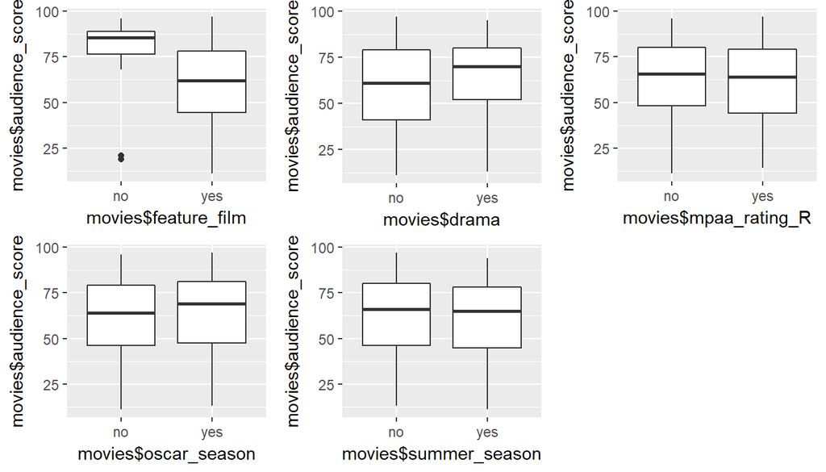

```r
p1 <- ggplot(data=movies, aes(x=movies$feature_film,y=movies$audience_score)) + geom_boxplot()
p2 <- ggplot(data=movies, aes(x=movies$drama,y=movies$audience_score)) + geom_boxplot()
p3 <- ggplot(data=movies, aes(x=movies$mpaa_rating_R,y=movies$audience_score)) + geom_boxplot()
p4 <- ggplot(data=movies, aes(x=movies$oscar_season,y=movies$audience_score)) + geom_boxplot()
p5 <- ggplot(data=movies, aes(x=movies$summer_season,y=movies$audience_score)) + geom_boxplot()

grid.arrange(p1, p2, p3, p4, p5, ncol=3)
```

- This boxplot shows that apart from a few outliers, movies that are not feature films tend to garner a bigger audience score. The feature movies group have a lower audience rating.
- Drama movies seem to have higher audience rating and a bigger median audience score with similar variability.
- R rated movies seem to have a lower median audience score but the results are mostly similar. There is no difference in the audience score between whether a movie is R rated or not.
- Movies in the Oscar season have a higher audience score with similar variability to those who are not in the Oscar season.
- It seems there is no difference in the audience score between whether a movie is in the summer season or not. Movies in summer season appear to have a smaller median audience score than those not in summer season.

## Part 4: Modeling

Next step will be developing a Bayesian Regression Model to predict the audience_score from the variables mentioned above. This model is created as follows:

```r
moviesNan = na.omit(movies)
modelReg = lm( data=moviesNan, log(audience_score) ~ feature_film + drama + runtime
                  + mpaa_rating_R + thtr_rel_year + oscar_season + summer_season
                  + imdb_rating + imdb_num_votes + critics_score + best_pic_nom
                  + best_pic_win + best_actor_win + best_actress_win
                  + best_dir_win + top200_box)
BIC(modelReg)
```

```
## [1] -117.7922
```

```r
summary(modelReg)
```

```
##
## Call:
## lm(formula = log(audience_score) ~ feature_film + drama + runtime +
##     mpaa_rating_R + thtr_rel_year + oscar_season + summer_season +
##     imdb_rating + imdb_num_votes + critics_score + best_pic_nom +
##     best_pic_win + best_actor_win + best_actress_win + best_dir_win +
##     top200_box, data = moviesNan)
##
## Residuals:
##      Min       1Q   Median       3Q      Max
## -0.99585 -0.08241  0.00654  0.09267  1.09511
##
## Coefficients:
##                       Estimate Std. Error t value Pr(>|t|)
## (Intercept)          2.740e+00  1.645e+00   1.665   0.0964 .
## feature_filmyes      6.470e-02  3.779e-02   1.712   0.0874 .
## dramayes             1.026e-02  1.811e-02   0.566   0.5714
## runtime             -9.144e-04  5.143e-04  -1.778   0.0759 .
## mpaa_rating_Ryes    -3.031e-02  1.695e-02  -1.788   0.0742 .
## thtr_rel_year       -3.253e-04  8.129e-04  -0.400   0.6892
## oscar_seasonyes     -1.014e-02  2.099e-02  -0.483   0.6292
## summer_seasonyes     1.874e-02  1.974e-02   0.949   0.3428
## imdb_rating          3.049e-01  1.279e-02  23.843   <2e-16 ***
## imdb_num_votes      -7.932e-08  9.301e-08  -0.853   0.3941
## critics_score        9.510e-04  4.624e-04   2.057   0.0401 *
## best_pic_nomyes      3.472e-02  5.365e-02   0.647   0.5178
## best_pic_winyes     -2.672e-02  9.394e-02  -0.284   0.7761
## best_actor_winyes   -2.453e-02  2.438e-02  -1.006   0.3147
## best_actress_winyes -3.581e-02  2.675e-02  -1.339   0.1812
## best_dir_winyes     -2.770e-02  3.527e-02  -0.785   0.4326
## top200_boxyes        2.410e-02  5.675e-02   0.425   0.6712
## ---
## Signif. codes:  0 '***' 0.001 '**' 0.01 '*' 0.05 '.' 0.1 ' ' 1
##
## Residual standard error: 0.2032 on 602 degrees of freedom
## Multiple R-squared:  0.7369, Adjusted R-squared:  0.7299
## F-statistic: 105.4 on 16 and 602 DF,  p-value: < 2.2e-16
```

The BIC of the full model is -117.7922.

```r
elimination <- stepAIC(modelReg, trace=0)
elimination
```

```
##
## Call:
## lm(formula = log(audience_score) ~ feature_film + runtime + mpaa_rating_R +
##     imdb_rating + critics_score, data = moviesNan)
##
## Coefficients:
##      (Intercept)   feature_filmyes           runtime  mpaa_rating_Ryes
##         2.149933          0.060672         -0.001293         -0.030444
##      imdb_rating     critics_score
##         0.300842          0.001054
```

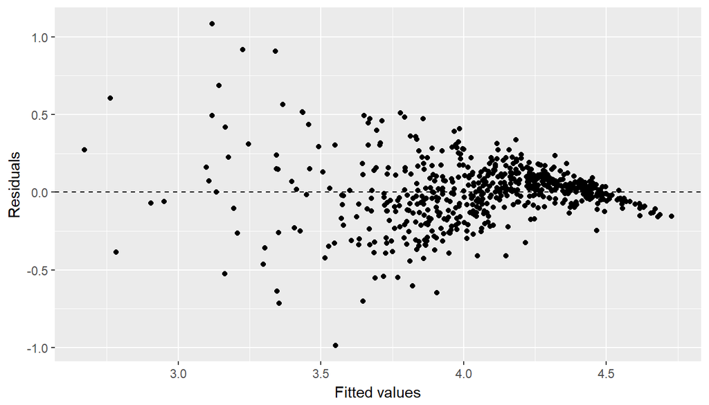

```r
ggplot(data = elimination, aes(x = .fitted, y = .resid)) +
  geom_point() +
  geom_hline(yintercept = 0, linetype = "dashed") +
  xlab("Fitted values") +
  ylab("Residuals")
```

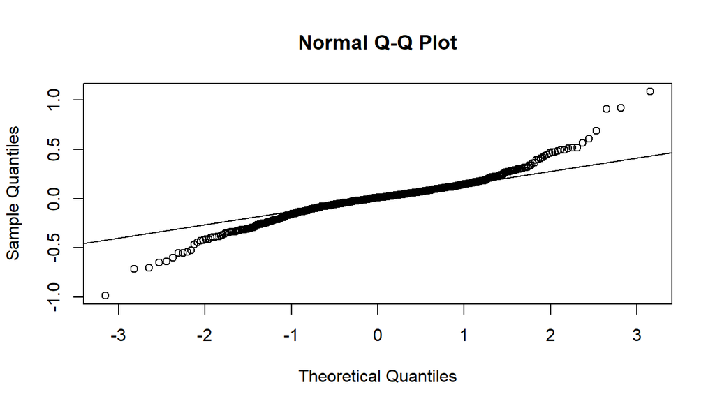

```r
qqnorm(elimination$residuals)
qqline(elimination$residuals)
```

According to the diagnostics, there are residuals with large values for low BMA predictions, indicated that the observed values are greater than the predicted values. The assumption of equal variance also seems to not being fulfilled in this model due to the residuals not being spread equally along the range of the predictors, signifying the presence of a non-linear relationship between the predictors.

```r
elimination$coefficients
```

```
##      (Intercept)  feature_filmyes          runtime mpaa_rating_Ryes
##      2.149932805      0.060672302     -0.001292948     -0.030444080
##      imdb_rating    critics_score
##      0.300842434      0.001053631
```

If the movie is feature, then the expected log of the audience score will increase by 0.06 while keeping all other variables the same. If the runtime increase by 1 minutes, then the expected log of the audience score will decrease by -0.0013 while keeping all other variables the same.

## Part 5: Prediction

We are going to use the model developed earlier to predict the audience score for the new movie from 2016 that is not included in the sample. Movie “Moonlight”, categorized as drama, on the Rotten Tomatoes website has a 98% rating (critics score). New data frame will be created for this movie.

```r
moviePredict <- data.frame(runtime = 110, mpaa_rating_R = 'yes', feature_film = 'yes', drama = 'yes', oscar_season = 'yes', summer_season = 'no', imdb_num_votes = 190729, thtr_rel_year = 2016, imdb_rating = 7.4, critics_score = 98, best_pic_nom = 'yes', best_pic_win = 'yes', best_actor_win = 'no', best_actress_win = 'no', best_dir_win = 'no', top200_box = 'no')

exp(predict(elimination, moviePredict, interval = "prediction", level = 0.95))
```

```
##        fit      lwr      upr
## 1 78.84048 52.88341 117.5382
```

The model predicts, with 95% confidence, that drama “Moonlight” is expected to have an audience score between 52.88 and 117.54. Our prediction interval contains actual audience score from the Rotten Tomatoes website (79).